# EXAMINING RED WINE QUALITY by RAGHAV BATRA

Data courtesy of:

P. Cortez, A. Cerdeira, F. Almeida, T. Matos and J. Reis. Modeling wine preferences by data mining from physicochemical properties. In Decision Support Systems, Elsevier, 47(4):547-553. ISSN: 0167-9236.

This data set contains 1,599 red wines with 11 variables on the chemical properties of the wine. At least 3 wine experts rated the quality of each wine, providing a rating between 0 (very bad) and 10 (very excellent).

This is an initial description of the data:

```
## 'data.frame':    1599 obs. of  13 variables:
##  $ X                   : int  1 2 3 4 5 6 7 8 9 10 ...
##  $ fixed.acidity       : num  7.4 7.8 7.8 11.2 7.4 7.4 7.9 7.3 7.8 7.5 ...
##  $ volatile.acidity    : num  0.7 0.88 0.76 0.28 0.7 0.66 0.6 0.65 0.58 0.5 ...
##  $ citric.acid         : num  0 0 0.04 0.56 0 0 0.06 0 0.02 0.36 ...
##  $ residual.sugar      : num  1.9 2.6 2.3 1.9 1.9 1.8 1.6 1.2 2 6.1 ...
##  $ chlorides           : num  0.076 0.098 0.092 0.075 0.076 0.075 0.069 0.065 0.073 0.071 ...
##  $ free.sulfur.dioxide : num  11 25 15 17 11 13 15 15 9 17 ...
##  $ total.sulfur.dioxide: num  34 67 54 60 34 40 59 21 18 102 ...
##  $ density             : num  0.998 0.997 0.997 0.998 0.998 ...
##  $ pH                  : num  3.51 3.2 3.26 3.16 3.51 3.51 3.3 3.39 3.36 3.35 ...
##  $ sulphates           : num  0.56 0.68 0.65 0.58 0.56 0.56 0.46 0.47 0.57 0.8 ...
##  $ alcohol             : num  9.4 9.8 9.8 9.8 9.4 9.4 9.4 10 9.5 10.5 ...
##  $ quality             : int  5 5 5 6 5 5 5 7 7 5 ...
```

```
##        X          fixed.acidity   volatile.acidity  citric.acid
##  Min.   :   1.0   Min.   : 4.60   Min.   :0.1200   Min.   :0.000
##  1st Qu.: 400.5   1st Qu.: 7.10   1st Qu.:0.3900   1st Qu.:0.090
##  Median : 800.0   Median : 7.90   Median :0.5200   Median :0.260
##  Mean   : 800.0   Mean   : 8.32   Mean   :0.5278   Mean   :0.271
##  3rd Qu.:1199.5   3rd Qu.: 9.20   3rd Qu.:0.6400   3rd Qu.:0.420
##  Max.   :1599.0   Max.   :15.90   Max.   :1.5800   Max.   :1.000
##  residual.sugar     chlorides       free.sulfur.dioxide
##  Min.   : 0.900   Min.   :0.01200   Min.   : 1.00
##  1st Qu.: 1.900   1st Qu.:0.07000   1st Qu.: 7.00
##  Median : 2.200   Median :0.07900   Median :14.00
##  Mean   : 2.539   Mean   :0.08747   Mean   :15.87
##  3rd Qu.: 2.600   3rd Qu.:0.09000   3rd Qu.:21.00
##  Max.   :15.500   Max.   :0.61100   Max.   :72.00
##  total.sulfur.dioxide    density             pH          sulphates
##  Min.   :  6.00       Min.   :0.9901   Min.   :2.740   Min.   :0.3300
##  1st Qu.: 22.00       1st Qu.:0.9956   1st Qu.:3.210   1st Qu.:0.5500
##  Median : 38.00       Median :0.9968   Median :3.310   Median :0.6200
##  Mean   : 46.47       Mean   :0.9967   Mean   :3.311   Mean   :0.6581
##  3rd Qu.: 62.00       3rd Qu.:0.9978   3rd Qu.:3.400   3rd Qu.:0.7300
##  Max.   :289.00       Max.   :1.0037   Max.   :4.010   Max.   :2.0000
##     alcohol         quality
##  Min.   : 8.40   Min.   :3.000
##  1st Qu.: 9.50   1st Qu.:5.000
##  Median :10.20   Median :6.000
##  Mean   :10.42   Mean   :5.636
##  3rd Qu.:11.10   3rd Qu.:6.000
##  Max.   :14.90   Max.   :8.000
```

```r
# change column name of 'X' to 'id' for simplicity
colnames(redWine)[1] = 'id'
```

# Univariate Plots Section

> **Tip**: In this section, you should perform some preliminary exploration of your dataset. Run some summaries of the data and create univariate plots to understand the structure of the individual variables in your dataset. Don’t forget to add a comment after each plot or closely-related group of plots! There should be multiple code chunks and text sections; the first one below is just to help you get started.

#### Histogram of quality of alcohol

It seems like that most of the wine is between a quality of 5 and 6, with the mean close to 6. The plot is pretty symmetrical.

The black line signifies the mean value.

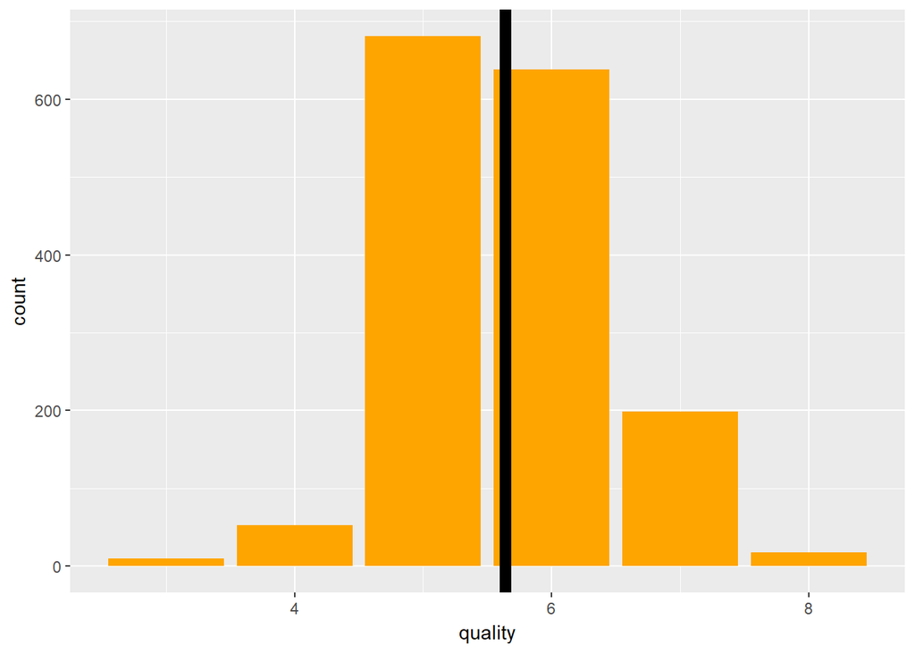

```r
# look at values of high quality wines
high_quality = subset(redWine, redWine$quality == 8)
head(high_quality)
```

```
##      id fixed.acidity volatile.acidity citric.acid residual.sugar
## 268 268           7.9             0.35        0.46            3.6
## 279 279          10.3             0.32        0.45            6.4
## 391 391           5.6             0.85        0.05            1.4
## 441 441          12.6             0.31        0.72            2.2
## 456 456          11.3             0.62        0.67            5.2
## 482 482           9.4             0.30        0.56            2.8
##     chlorides free.sulfur.dioxide total.sulfur.dioxide density   pH
## 268     0.078                  15                   37  0.9973 3.35
## 279     0.073                   5                   13  0.9976 3.23
## 391     0.045                  12                   88  0.9924 3.56
## 441     0.072                   6                   29  0.9987 2.88
## 456     0.086                   6                   19  0.9988 3.22
## 482     0.080                   6                   17  0.9964 3.15
##     sulphates alcohol quality
## 268      0.86    12.8       8
## 279      0.82    12.6       8
## 391      0.82    12.9       8
## 441      0.82     9.8       8
## 456      0.69    13.4       8
## 482      0.92    11.7       8
```

#### Histogram of pH of alcohol

It seems that indeed all alcohols are acidic (below 7, top graph), concentrated near 3.3. The plot is also very symmetrical (pH levels, bottom graph).

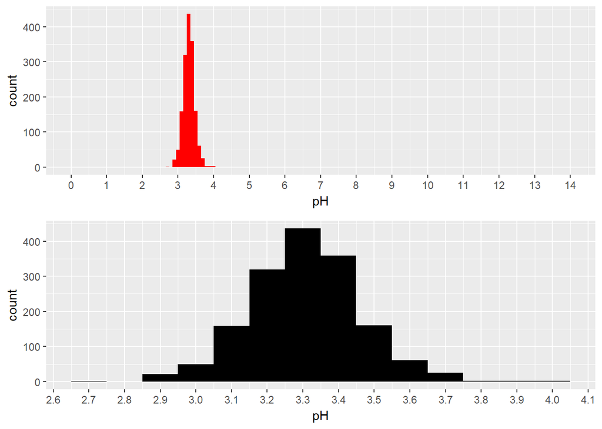

```
##    Min. 1st Qu.  Median    Mean 3rd Qu.    Max.
##   2.740   3.210   3.310   3.311   3.400   4.010
```

#### Points of residual sugar

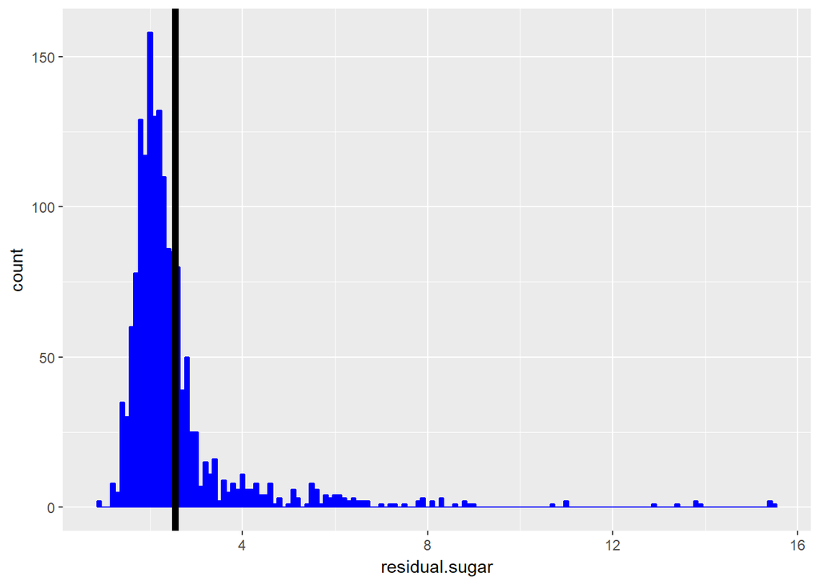

Transforming the long tail of the above graph, we get this.

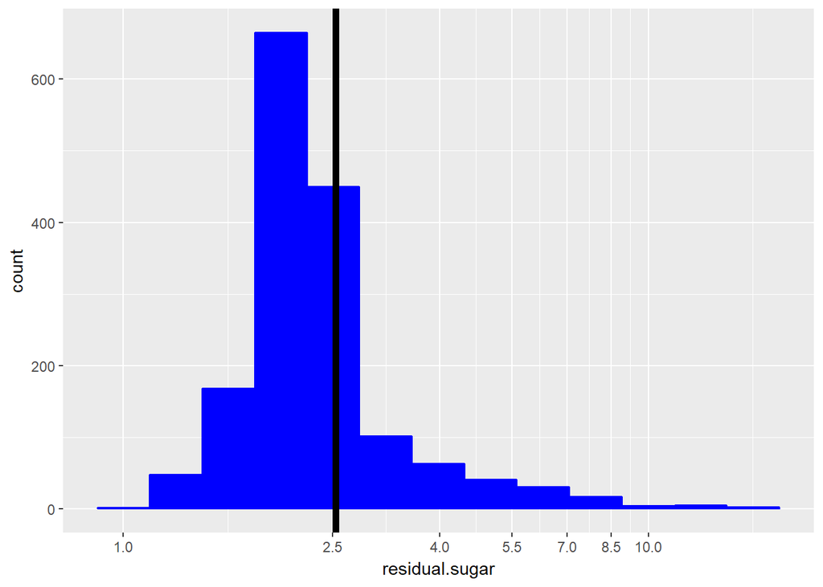

```
##    Min. 1st Qu.  Median    Mean 3rd Qu.    Max.
##   0.900   1.900   2.200   2.539   2.600  15.500
```

#### Excess residual sugar quality

Let us investigate the quality of the wines with residual sugar > 10 further.

From the graph below, it seems that such wines are close to 6, around the same as the mean value for the whole dataset. This makes sense since excess sugar will change the taste of the wine.

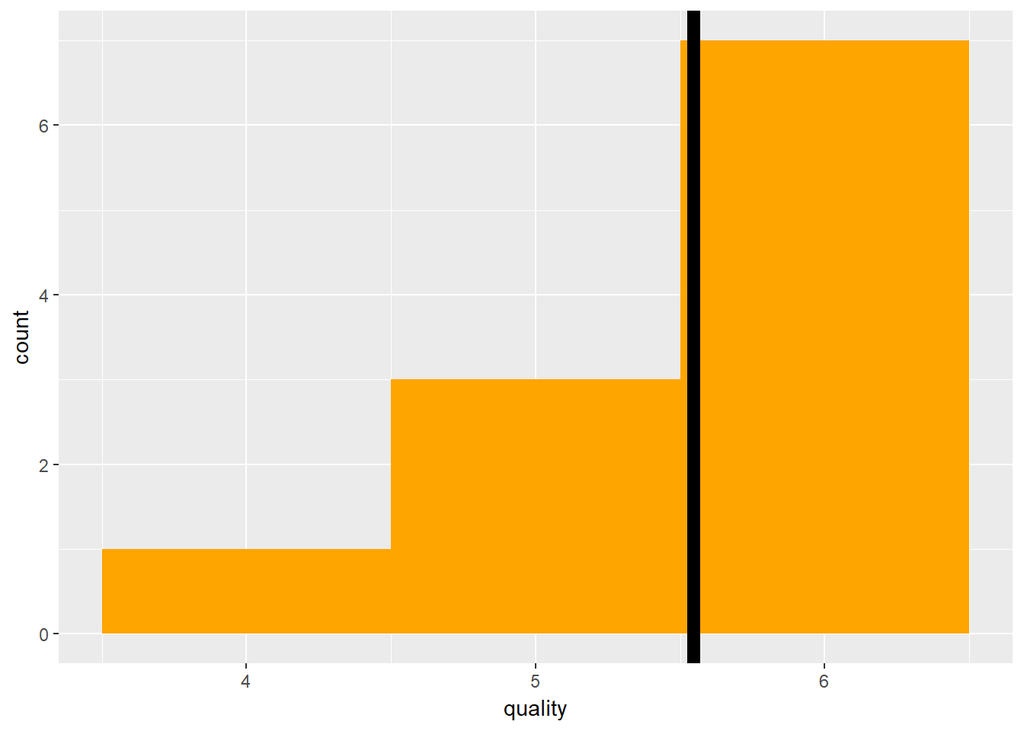

```
##    Min. 1st Qu.  Median    Mean 3rd Qu.    Max.
##   4.000   5.000   6.000   5.545   6.000   6.000
```

#### Bar charts for SO2 levels evident

As per the variable descriptions, I created a new logical variable if the wine contains more than 50 ppm.

It is evident from the graph below that almost a third of alcohols have such a concentration.

```r
# new caregorical variable: definition of excess SO2
redWine$freeSO2evident = redWine$total.sulfur.dioxide > 50

summary(redWine$freeSO2evident)
```

```
##    Mode   FALSE    TRUE
## logical    1053     546
```

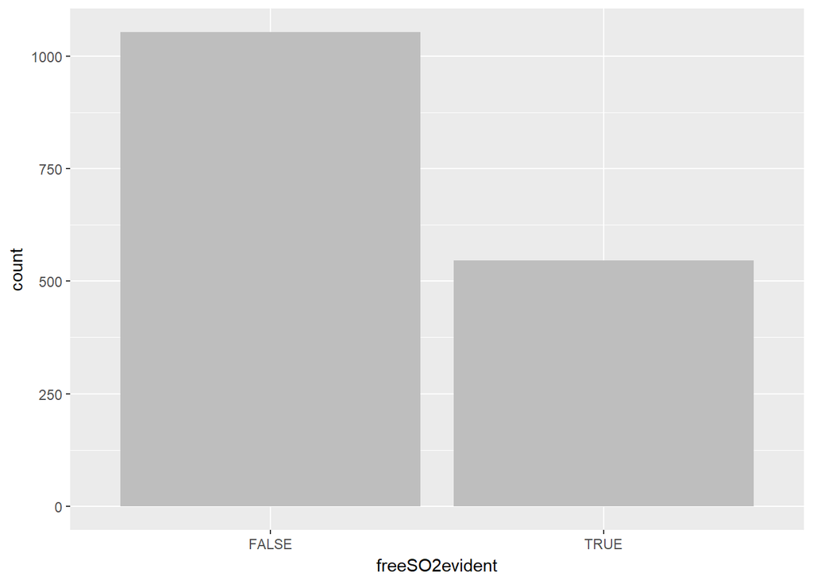

```r
ggplot(data = redWine, aes(x = freeSO2evident, fill = I('grey')) ) +
  geom_bar(stat = "count")
```

Let us examine how the quality varies for this kind of wine.

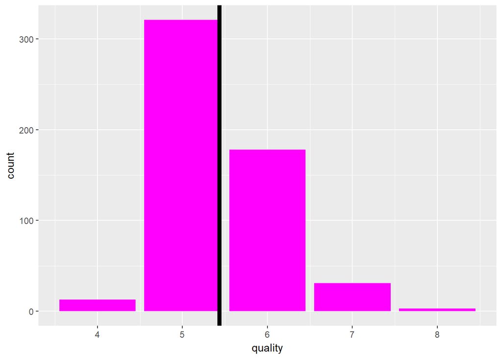

```
##    Min. 1st Qu.  Median    Mean 3rd Qu.    Max.
##   4.000   5.000   5.000   5.432   6.000   8.000
```

From the graph above, it again seems that such wines are around the same as the mean value for the whole dataset. This makes sense since excess SO2 will cause a pungent smell.

Let us examine the SO2 levels in a different way by creating another variable that measures the free SO2 as a percentage of the total SO2.

```r
# new variable: definition of free SO2 percent
redWine$freeSO2percent = redWine$free.sulfur.dioxide/redWine$total.sulfur.dioxide
```

The graph below shows a large spike at 50% concentrations. This may make sense as free SO2 is used for preventation against microbes, so the halfway mark seems likes a good place for most wines: not too much and not too little

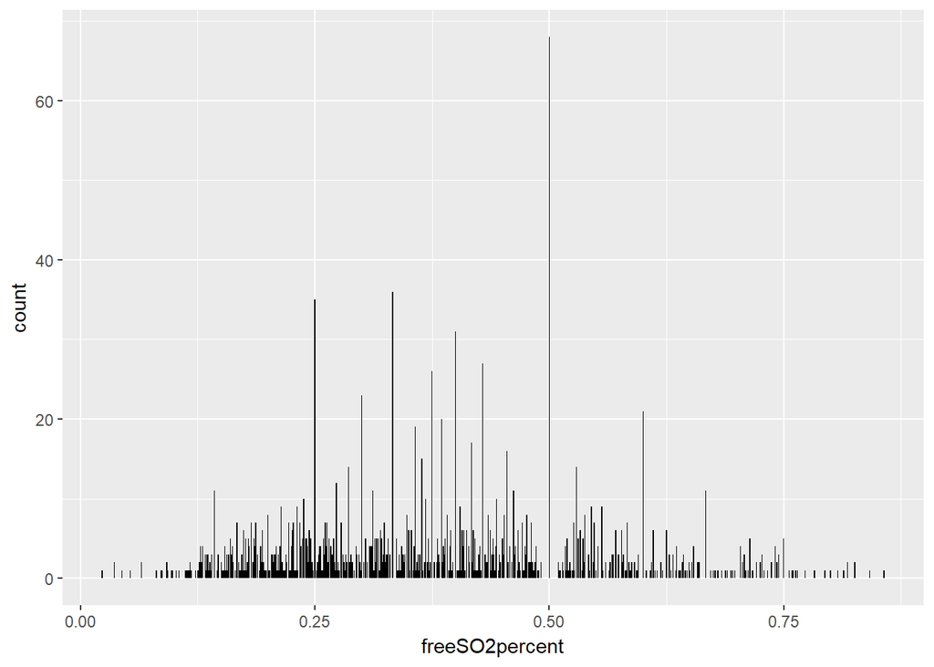

```
##    Min. 1st Qu.  Median    Mean 3rd Qu.    Max.
## 0.02273 0.25926 0.37500 0.38231 0.48485 0.85714
```

#### Histogram for chloride levels

It can be seen that that from 0.03 upto a level of 0.012, there is an almost perfect bell curve. So far, this plot has the most outliers.

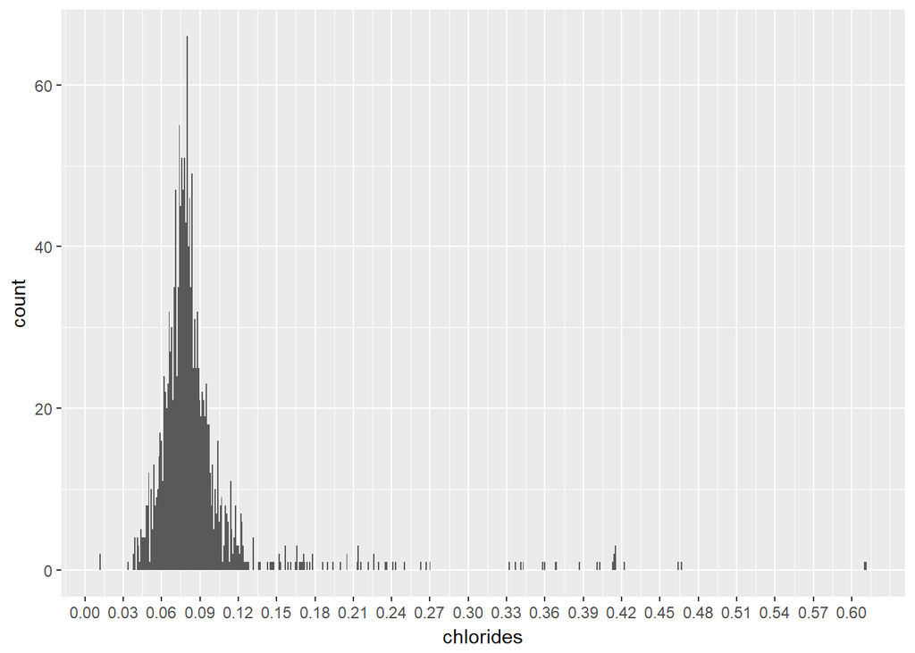

```
##    Min. 1st Qu.  Median    Mean 3rd Qu.    Max.
## 0.01200 0.07000 0.07900 0.08747 0.09000 0.61100
```

#### Number of values outside ‘bell curve’ range

```
## [1] 12.50782
```

A whopping 12.5% of data is outside the ‘bell curve’!

Let us visualize the above plot without these outliers.

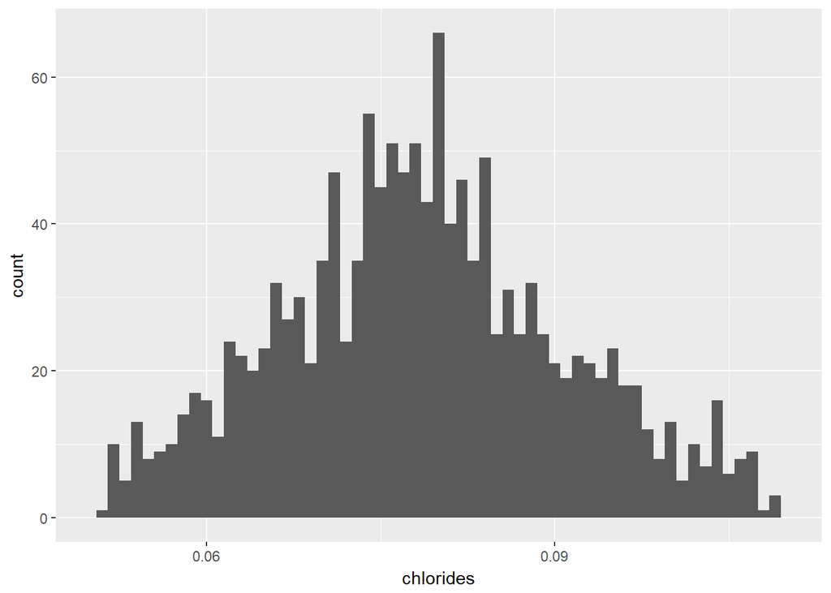

#### Histogram of fixed acidity

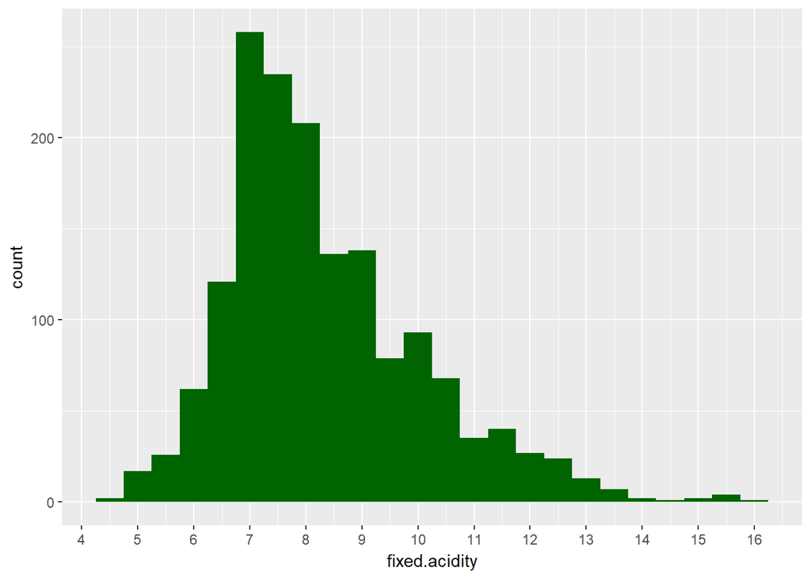

```
##    Min. 1st Qu.  Median    Mean 3rd Qu.    Max.
##    4.60    7.10    7.90    8.32    9.20   15.90
```

#### Histogram of volatile acidity

Data in this graph is more concentrated than in the previous one. The levels seem to be between 0.3 and 0.7

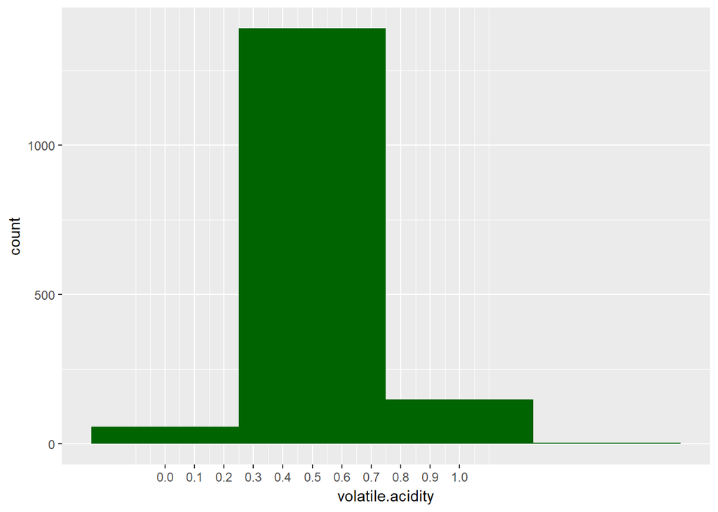

```
##    Min. 1st Qu.  Median    Mean 3rd Qu.    Max.
##  0.1200  0.3900  0.5200  0.5278  0.6400  1.5800
```

Let us see this in terms of our data. Below is the number of wines whose volatile acidity is between 0.3 and 0.7 (inclusive).

```
##       x freq
## 1 FALSE  350
## 2  TRUE 1249
```

#### Histogram of citric acid levels

There seems to be a spike at 0.0, which should be alarming. However, after performing some research, I read that red wines, in general, do not have much (if any) levels of citric acid due to “ggressive citric flavors it can add to the wine.” (Wikipedia)

Given this fact, the spike at 0.5 seems weird. Let’s explore it!

This graph is also unusual in the fact that any transformation to the x-axis results in similar graphs.

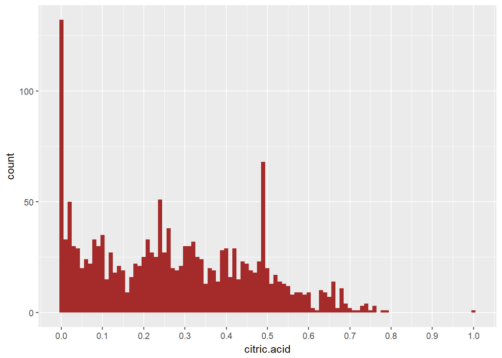

```
##    Min. 1st Qu.  Median    Mean 3rd Qu.    Max.
##   0.000   0.090   0.260   0.271   0.420   1.000
```

```r
citric_spikes = subset(redWine, redWine$citric.acid == 0.5)
print (mean(citric_spikes$quality))
```

```
## [1] 5.65
```

```r
print (head(citric_spikes))
```

```
##      id fixed.acidity volatile.acidity citric.acid residual.sugar
## 227 227           8.9             0.59         0.5            2.0
## 328 328          10.3             0.44         0.5            4.5
## 341 341          12.2             0.34         0.5            2.4
## 345 345          11.9             0.57         0.5            2.6
## 366 366          10.0             0.42         0.5            3.4
## 377 377          11.5             0.45         0.5            3.0
##     chlorides free.sulfur.dioxide total.sulfur.dioxide density   pH
## 227     0.337                  27                   81  0.9964 3.04
## 328     0.107                   5                   13  0.9980 3.28
## 341     0.066                  10                   21  1.0000 3.12
## 345     0.082                   6                   32  1.0006 3.12
## 366     0.107                   7                   21  0.9979 3.26
## 377     0.078                  19                   47  1.0003 3.26
##     sulphates alcohol quality freeSO2evident freeSO2percent
## 227      1.61     9.5       6           TRUE      0.3333333
## 328      0.83    11.5       5          FALSE      0.3846154
## 341      1.18     9.2       6          FALSE      0.4761905
## 345      0.78    10.7       6          FALSE      0.1875000
## 366      0.93    11.8       6          FALSE      0.3333333
## 377      1.11    11.0       6          FALSE      0.4042553
```

Looking at the mean wine quality (5.65; very close to mean of entire set), and other indicators, I found that even though there is a spike in citric acid levels, these data points are not outliers.

#### Histogram of alcohol percent levels

There is a long tail, and it seems alcohol percent levels spike at around 9.5. The general distribution is consistent with outside

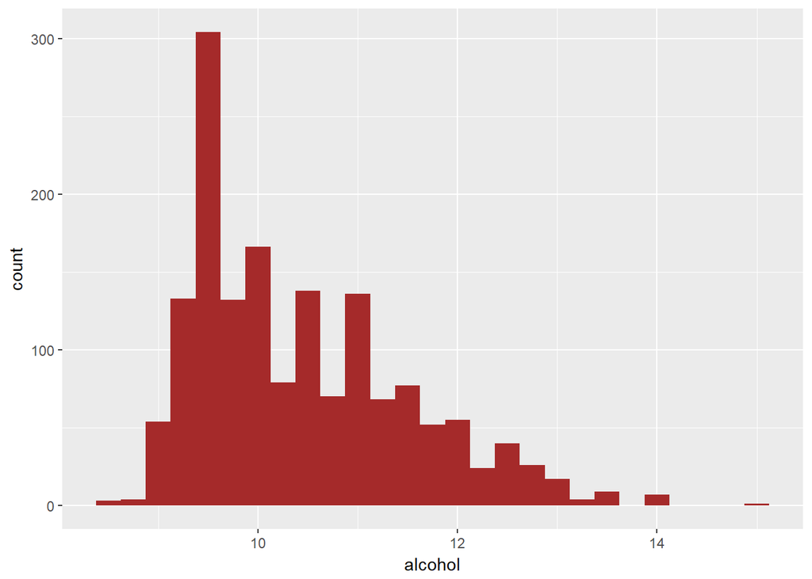

Transforming the tail gives this:

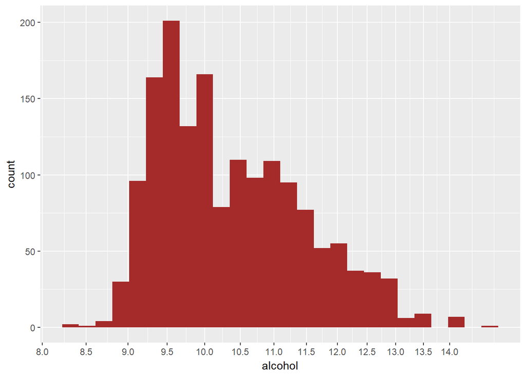

```
##    Min. 1st Qu.  Median    Mean 3rd Qu.    Max.
##    8.40    9.50   10.20   10.42   11.10   14.90
```